# Vis Theory

Information & Interaction Design

Mick McQuaid

mcq@utexas.edu

University of Texas at Austin

20 Aug 2026

# Week FOURTEEN

# grammar of graphics

## Wilkinson (2005)

chapter 2, how to make a pie

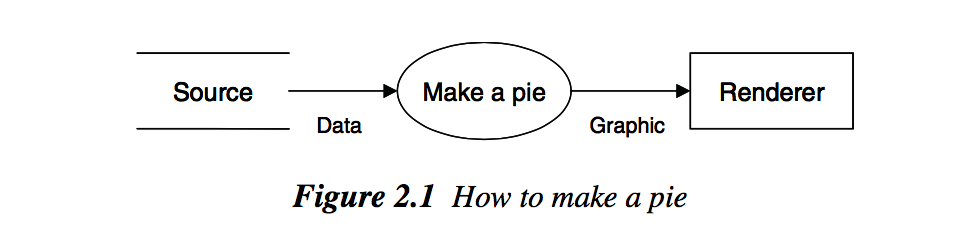

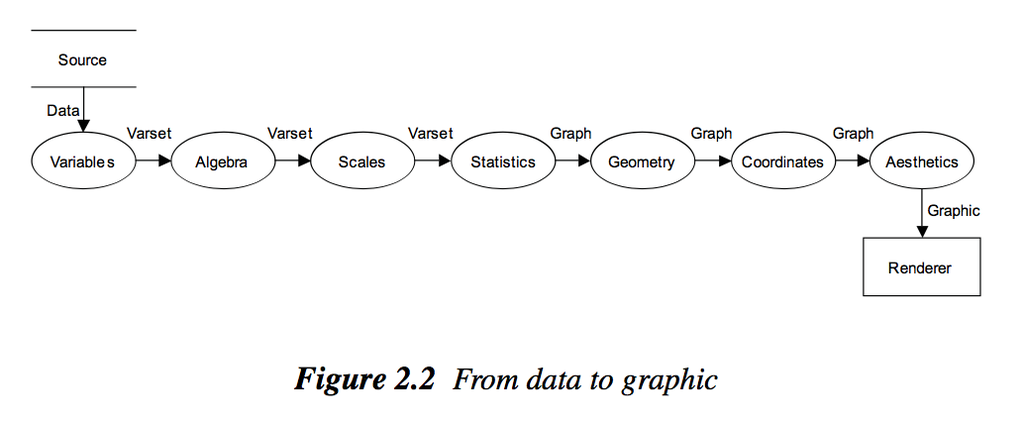

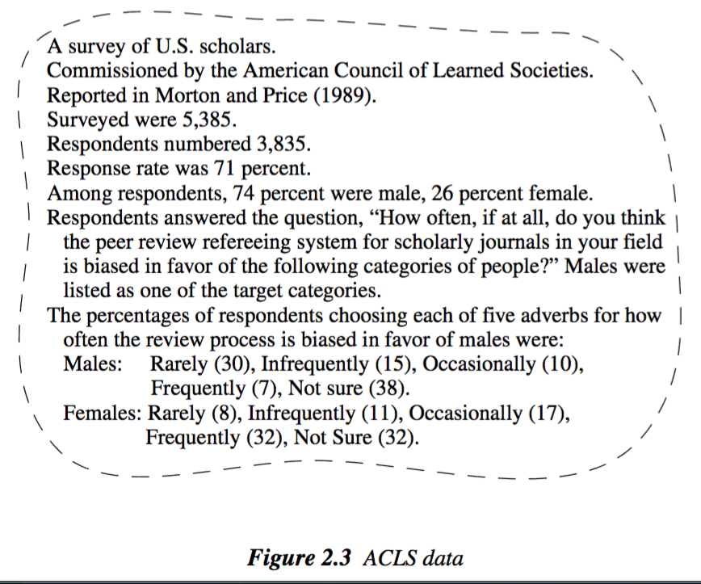

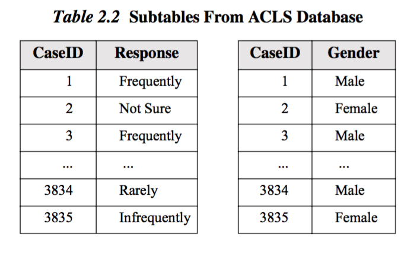

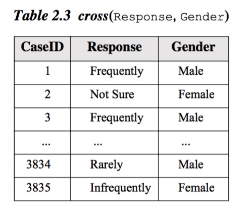

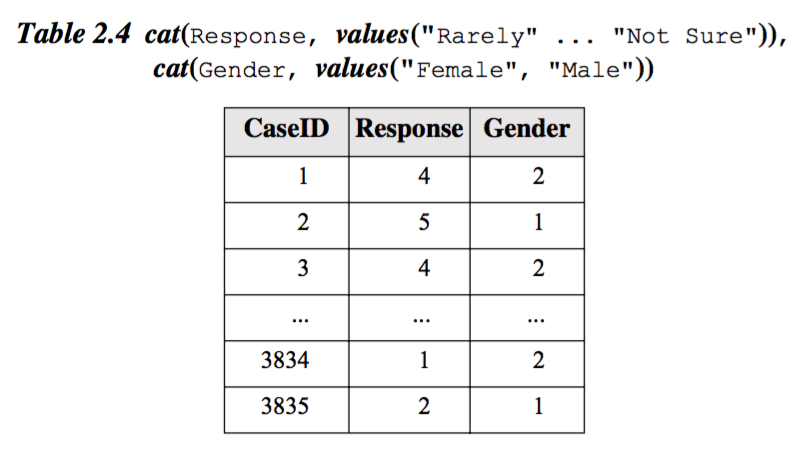

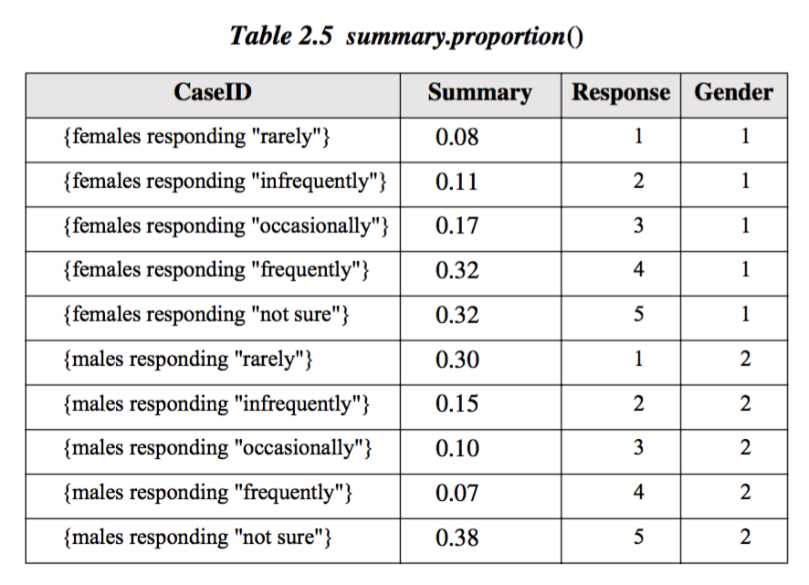

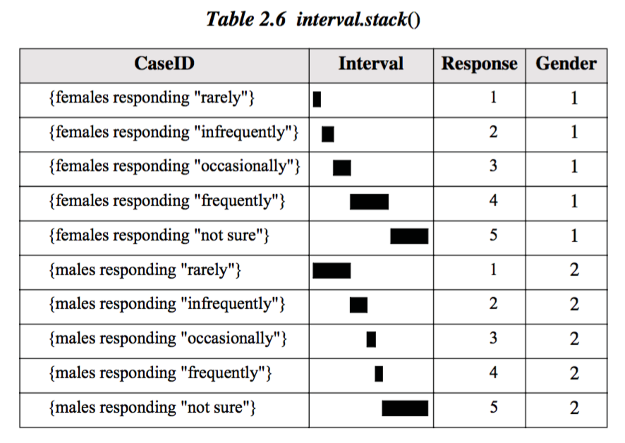

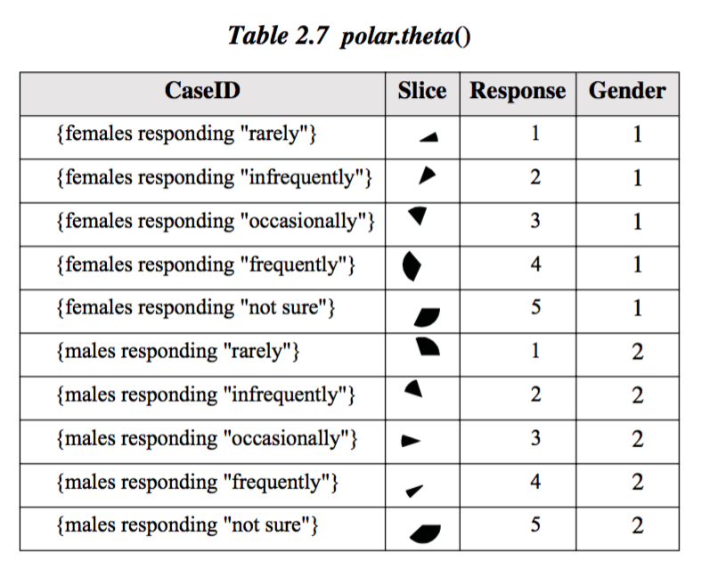

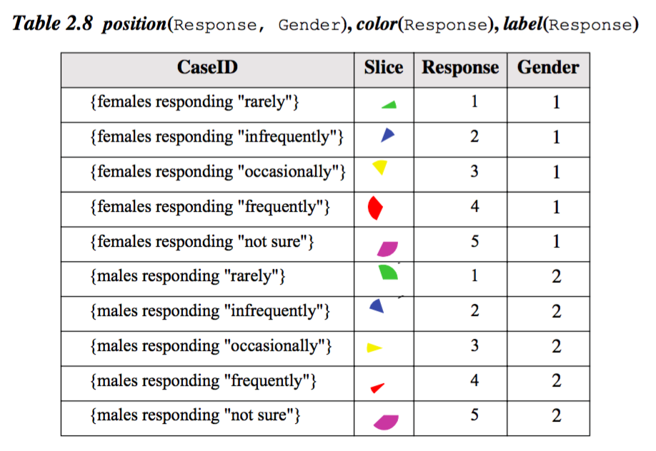

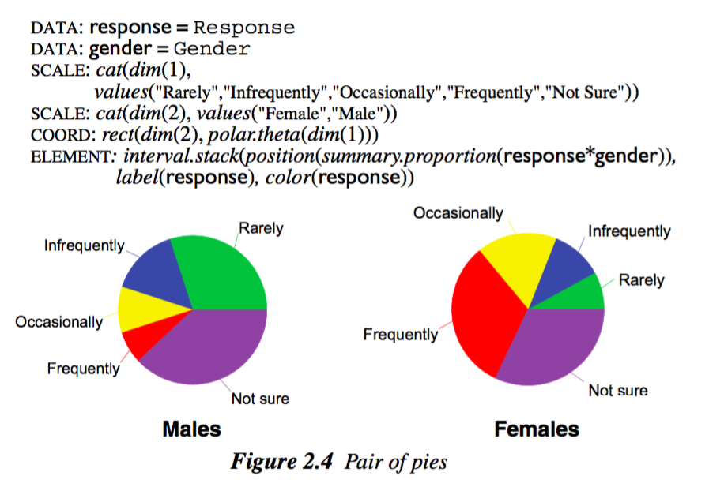

## CODA

Syntax and Semantics

Subsequent chapters of Part I treat each of the concepts

The GoG also includes semantics

Semantics include space, time, and uncertainty

These concepts are treated mathematically in Part II of GoG

Part II

## Semantics

We could look at any of the chapters, such as Time or Uncertainty, but we’ll just look at Space for now

## Space

Four perspectives on space

- Terminology
- Mathematical Space
- Psychological Space
- Graphing Space

## Two kinds of space

- preceding definitions say that a graph is just a concept, not what we see: the graphic is what we see
- this means there are two kinds of space
- - underlying space (any space with a mathematical definition)
  - represented space (what we see: always 2$D$ or 3$D$)

## Example: beadlet anemones

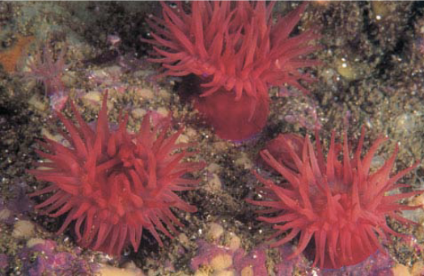

## A minimum spanning tree of a rock covered with beadlet anemones

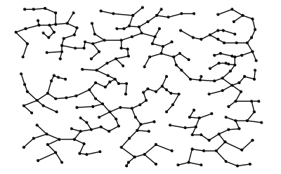

## A different layout of the same tree

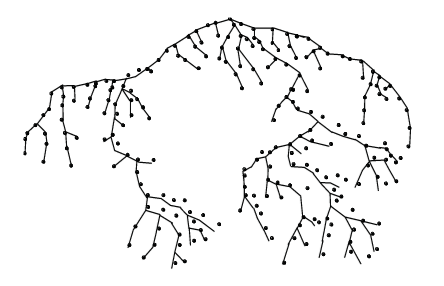

## Display space and underlying space

The display space and the underlying space can have different relationships. If the display space misses information about the underlying space, we may not be able to understand the graphic. The graphic may reflect only part of the graph.

## Graphics as a mapping function

$f: S\rightarrow P$, where $S$ is the underlying mathematical space and $P$ is a Euclidean displace space represented by a *position* aesthetic. (Aesthetics are the things you can see, like texture, orientation, color, etc.)

To fully understand the graphic, you need to know the function $f$ and the underlying mathematical space $S$.

## Three perspectives on space

- Mathematical
- Psychological
- Graphical

## Mathematical space

Mathematical spaces have topological properties, for instance

- values may be on a continuum
- values may be categorical and hence isolated from each other
- values may lie in a compact region
- values may lie in an unbounded region

## Topological space

- a topological space $S$ is a set $X$ and a collection $T$ of subsets of $X$ satisfying these axioms
- - the empty set and $X$ are in $T$
  - the union of any number of sets in $T$ is also in $T$
  - the intersection of any two sets in $T$ is also in $T$

## Yet more terms

- the elements of $X$ are points
- The set $T$ is a topology on $X$
- the elements of $T$ are the open sets of $X$
- a subset of $X$ is closed if its complement is open
- any set $B$ is a basis for $T$ if every member of $T$ is a union of members of $B$

## Using the terms

We could go on to define topologies of the real number line using the previous definitions, but for now we’ll just consider connected, totally disconnected, and discrete spaces

## Connected spaces

We can draw a line between any two points and that line can be meaningful, for example the two points could be temperatures and the line could represent the number of degrees between those temperatures

## Totally disconnected spaces

Each point is in a category so you can’t draw a meaningful line between the categories. For example, each point is a species of bird and a line between two of them has no metric meaning

# END

# References

Wilkinson, Leland. 2005. *The Grammar of Graphics (Statistics and Computing)*. Springer-Verlag.

# Colophon

This slideshow was produced using `quarto`

Fonts are *Fira Sans*, *Fira Sans Light*, and *Victor Mono Nerd Font*

Math is set in *Fira Math* via *MathJax 4*